# 机器学习与数据挖掘比赛

- 作者：顾全

# 比赛1：Amazon项目

### 【目录】

- 1.数据加载和处理
- 2.独热编码
- 3.逻辑回归
  - 3.1 第一次:不调参
  - 3.2 第二次:Lasso
  - 3.3 第三次:Ridge
- 4.随机森林
  - 4.1 随机森林分类
  - 4.2 随机森林回归

## 1.数据加载和处理

```python
from sklearn import (metrics, cross_validation, linear_model, preprocessing)
import numpy as np
import pandas as pd
%matplotlib inline
import matplotlib.pyplot as plt
import seaborn as sns
```

```python
import   os
os.chdir('C:\\Users\\GuQuan\\Desktop\\amazon')
```

```python
train = pd.read_csv("train.csv")
test = pd.read_csv("test.csv")
data_all = pd.concat([train, test])
```

```python
train.describe()
```

|  | ACTION | RESOURCE | MGR_ID | ROLE_ROLLUP_1 | ROLE_ROLLUP_2 | ROLE_DEPTNAME | ROLE_TITLE | ROLE_FAMILY_DESC | ROLE_FAMILY | ROLE_CODE |
| --- | --- | --- | --- | --- | --- | --- | --- | --- | --- | --- |
| count | 32769.000000 | 32769.000000 | 32769.000000 | 32769.000000 | 32769.000000 | 32769.000000 | 32769.000000 | 32769.000000 | 32769.000000 | 32769.000000 |
| mean | 0.942110 | 42923.916171 | 25988.957979 | 116952.627788 | 118301.823156 | 118912.779914 | 125916.152644 | 170178.369648 | 183703.408893 | 119789.430132 |
| std | 0.233539 | 34173.892702 | 35928.031650 | 10875.563591 | 4551.588572 | 18961.322917 | 31036.465825 | 69509.462130 | 100488.407413 | 5784.275516 |
| min | 0.000000 | 0.000000 | 25.000000 | 4292.000000 | 23779.000000 | 4674.000000 | 117879.000000 | 4673.000000 | 3130.000000 | 117880.000000 |
| 25% | 1.000000 | 20299.000000 | 4566.000000 | 117961.000000 | 118102.000000 | 118395.000000 | 118274.000000 | 117906.000000 | 118363.000000 | 118232.000000 |
| 50% | 1.000000 | 35376.000000 | 13545.000000 | 117961.000000 | 118300.000000 | 118921.000000 | 118568.000000 | 128696.000000 | 119006.000000 | 118570.000000 |
| 75% | 1.000000 | 74189.000000 | 42034.000000 | 117961.000000 | 118386.000000 | 120535.000000 | 120006.000000 | 235280.000000 | 290919.000000 | 119348.000000 |
| max | 1.000000 | 312153.000000 | 311696.000000 | 311178.000000 | 286791.000000 | 286792.000000 | 311867.000000 | 311867.000000 | 308574.000000 | 270691.000000 |

```python
for i in range(len(data_all.T)) :
    print "%s : %d 种取值"%(data_all.columns[i],len(data_all.loc[:,data_all.columns[i]].unique()))
```

```
ACTION : 3 种取值
MGR_ID : 4913 种取值
RESOURCE : 7518 种取值
ROLE_CODE : 361 种取值
ROLE_DEPTNAME : 476 种取值
ROLE_FAMILY : 68 种取值
ROLE_FAMILY_DESC : 2951 种取值
ROLE_ROLLUP_1 : 130 种取值
ROLE_ROLLUP_2 : 183 种取值
ROLE_TITLE : 361 种取值
id : 58922 种取值
```

- 发现ROLE_TITLE和ROLE_CODE都取了361个值，怀疑这两列数据是重复的

```python
#计算总共有多少种取值
4913+7518+361+476+68+2951+130+183
```

```
16600
```

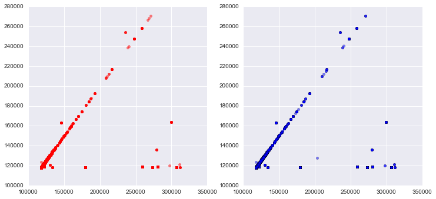

```python
plt.figure(figsize=(12,12))
ax1 = plt.subplot(221)
plt.scatter(train.loc[:,'ROLE_TITLE'],train.loc[:,'ROLE_CODE'],color='red',alpha=0.5)
ax2 = plt.subplot(222)
plt.scatter(test.loc[:,'ROLE_TITLE'],test.loc[:,'ROLE_CODE'],alpha=0.5)
plt.show()
```

- 可以看到，除了少量离群点外，不论是训练集还是测试集，TITLE和CODE这两组数据基本在一条直线上，为避免共线性问题，在分析中需要删除一列

```python
train1,test1=train.ix[:,0:-1],test.ix[:,0:-1]
X,y=train1.ix[:,1:].values,train1.ix[:,0].values#训练数据X，y
X_test=test1.ix[:,1:].values                            #测试数据X_test
```

```python
X.shape
```

```
(32769L, 8L)
```

## 2.独热编码

```python
#独热编码One-Hot Encoding示例
encoder = preprocessing.OneHotEncoder()
aaa=[[0, 0, 3], [1, 1, 0], [0, 2, 1], [1, 0, 2]]
encoder.fit(aaa)
aaa=encoder.transform(aaa)
print aaa.shape
aaa.toarray()
#第一列0,1有2种取值，第二列0,1,2有3种，第三列3,0,1,2有4种，共2+3+4=9种
```

```
(4, 9)
```

```
array([[ 1.,  0.,  1.,  0.,  0.,  0.,  0.,  0.,  1.],
       [ 0.,  1.,  0.,  1.,  0.,  1.,  0.,  0.,  0.],
       [ 1.,  0.,  0.,  0.,  1.,  0.,  1.,  0.,  0.],
       [ 0.,  1.,  1.,  0.,  0.,  0.,  0.,  1.,  0.]])
```

```python
#将训练集测试集的自变量按行合并，一起编码
encoder.fit(np.vstack((X, X_test)))
```

```
OneHotEncoder(categorical_features='all', dtype=<type 'float'>,
       handle_unknown='error', n_values='auto', sparse=True)
```

```python
X1 = encoder.transform(X)
X1_test = encoder.transform(X_test)
X1.shape
```

```
(32769, 16600)
```

- 共产生了16600个哑变量

## 3.逻辑回归

```python
from sklearn.linear_model import LogisticRegression
```

### 3.1 第一次：不调参

```python
model1 = linear_model.LogisticRegression() #C=1
```

```python
#定义一个交叉验证函数
SEED = 22
N=10
def cv_loop(X, y, model, N):#N折交叉验证
    mean_auc = 0.
    for i in range(N):
        #80%用于训练，20%用于测试
        X_train, X_cv, y_train, y_cv = cross_validation.train_test_split(
                                       X, y, test_size=.20, random_state = i*SEED)
        model.fit(X_train, y_train)
        preds = model.predict_proba(X_cv)[:,1]
        #计算AUC值
        fpr, tpr, thresholds = metrics.roc_curve(y_cv, preds)
        auc=metrics.auc(fpr, tpr)
        mean_auc += auc
    return mean_auc/N
```

```python
print "Mean AUC: %f" % (cv_loop(X1, y, model1, N))
```

```
Mean AUC: 0.858290
```

### 3.2 第二次：Lasso

```python
model2 = linear_model.LogisticRegression()
```

```python
model2.penalty='l1'#Lasso=L1-regularization
N=10
score_hist = []
Cvals = [0.1,0.5,1.5,3,5]
for C in Cvals:#循环寻找最佳惩罚项的系数C
    model2.C = C
    score = cv_loop(X1, y, model2, N)
    score_hist.append((score,C))
bestC = sorted(score_hist)[-1][1]
print "Best C value: %f" % (bestC)
model2.C = bestC
```

```
Best C value: 1.500000
```

```python
print "Mean AUC: %f" % ( cv_loop(X1, y, model2, N))
```

```
Mean AUC: 0.856943
```

### 3.3 第三次：Ridge

```python
model3 = linear_model.LogisticRegression()
```

```python
model3.penalty='l2'#Ridge=L2-regularization
score_hist = []
Cvals = [0.1,0.5,1.5,3,5]
for C in Cvals:#循环寻找最佳惩罚项的系数C
    model3.C = C
    score = cv_loop(X1, y, model3, N)
    score_hist.append((score,C))
bestC = sorted(score_hist)[-1][1]
print "Best C value: %f" % (bestC)
model3.C = bestC
```

```
Best C value: 3.000000
```

```python
print "Mean AUC: %f" % ( cv_loop(X1, y, model3, N))
```

```
Mean AUC: 0.860536
```

- 最终选择model3，正则化方式选Ridge，并令C=3

```python
#待提交的结果
model3.fit(X1, y)
preds_proba = model.predict_proba(X1_test)[:, 1]
preds_01=model.predict(X1_test)
pd.value_counts(model.predict(X1_test))
```

```
1    57628
0     1293
dtype: int64
```

## 4.随机森林

```python
from sklearn.ensemble import RandomForestClassifier
from sklearn.ensemble import RandomForestRegressor
```

### 4.1 随机森林分类

```python
forest1= RandomForestClassifier(n_estimators=1000)
```

```python
#80%训练，20%预测
X_train, X_cv, y_train, y_cv = cross_validation.train_test_split(X,y, test_size=.20)
forest1.fit(X_train, y_train)
predictions = forest1.predict(X_cv)
fpr, tpr, thresholds = metrics.roc_curve(y_cv, predictions)
roc_auc = metrics.auc(fpr, tpr)
print roc_auc
```

```
0.664258315449
```

- auc值只有0.66，准确度太低

### 4.2 随机森林回归

```python
forest2= RandomForestRegressor(n_estimators=1000)
```

```python
X_train, X_cv, y_train, y_cv = cross_validation.train_test_split(X,y, test_size=.20)
forest2.fit(X_train, y_train)
predictions = forest2.predict(X_cv)
fpr, tpr, thresholds = metrics.roc_curve(y_cv, predictions)
roc_auc = metrics.auc(fpr, tpr)
print roc_auc
```

```
0.855441595231
```

- 把这个分类问题强制作为回归问题求解，准确度反而比较高

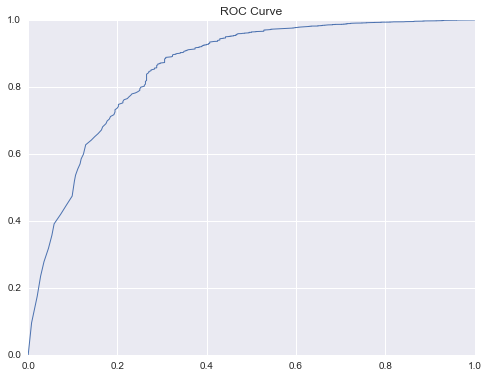

```python
#画ROC曲线
plt.figure(figsize=(8,6))
plt.plot(fpr, tpr, lw=1)
plt.title('ROC Curve')
plt.show()
```

### 附:也可以用10折交叉验证，不过运行会比较慢

> mean_auc = 0.0  
> n = 10  
> SEED=25  
> for i in range(n):  
> X_train, X_cv, y_train, y_cv = cross_validation.train_test_split(  
> X,y, test_size=.20, random_state=i*SEED)  
> forest.fit(X_train, y_train)  
> predictions = forest.predict(X_cv)  
> fpr, tpr, thresholds = metrics.roc_curve(y_cv, predictions)  
> roc_auc = metrics.auc(fpr, tpr)  
> print "AUC (fold %d/%d): %f" % (i + 1, n, roc_auc)  
> mean_auc += roc_auc  
> print "Mean AUC: %f" % (mean_auc/n)

### 【提交结果】

```python
def create_test_submission(filename, prediction):
    content = ['id,ACTION']
    for i, p in enumerate(prediction):
        content.append('%i,%f' %(i+1,p))
    f = open(filename, 'w')
    f.write('\n'.join(content))
    f.close()
    print 'Saved'
```

```python
#逻辑回归(概率)
create_test_submission('lg1.csv',preds_proba)
```

```
Saved
```

- 真实准确率为0.871,排名700

# 比赛2：数字识别

### 【目录】

- 1.获取与查看数据
- 2.特征工程
  - 2.1 像素处理
  - 2.2 特征提取
- 3.Logistic回归
  - 3.1 Ridge正则化
  - 3.2 Lasso正则化
- 4.K邻近算法
  - 4.1 KNN建模
  - 4.2 画混淆矩阵

```python
import pandas as pd
import numpy as np
```

## 1.获取与查看数据

```python
#获取数据
import   os
os.chdir('C:\\Users\\GuQuan\\Desktop\\digital')
train = pd.read_csv("train.csv")
test = pd.read_csv("test.csv").values
X_train = train.values[0:, 1:]
y_train = train.values[0:, 0]
```

```python
#查看数据
train.describe()
```

|  | label | pixel0 | pixel1 | pixel2 | pixel3 | pixel4 | pixel5 | pixel6 | pixel7 | pixel8 | ... | pixel774 | pixel775 | pixel776 | pixel777 | pixel778 | pixel779 | pixel780 | pixel781 | pixel782 | pixel783 |
| --- | --- | --- | --- | --- | --- | --- | --- | --- | --- | --- | --- | --- | --- | --- | --- | --- | --- | --- | --- | --- | --- |
| count | 42000.000000 | 42000 | 42000 | 42000 | 42000 | 42000 | 42000 | 42000 | 42000 | 42000 | ... | 42000.000000 | 42000.000000 | 42000.000000 | 42000.00000 | 42000.000000 | 42000.000000 | 42000 | 42000 | 42000 | 42000 |
| mean | 4.456643 | 0 | 0 | 0 | 0 | 0 | 0 | 0 | 0 | 0 | ... | 0.219286 | 0.117095 | 0.059024 | 0.02019 | 0.017238 | 0.002857 | 0 | 0 | 0 | 0 |
| std | 2.887730 | 0 | 0 | 0 | 0 | 0 | 0 | 0 | 0 | 0 | ... | 6.312890 | 4.633819 | 3.274488 | 1.75987 | 1.894498 | 0.414264 | 0 | 0 | 0 | 0 |
| min | 0.000000 | 0 | 0 | 0 | 0 | 0 | 0 | 0 | 0 | 0 | ... | 0.000000 | 0.000000 | 0.000000 | 0.00000 | 0.000000 | 0.000000 | 0 | 0 | 0 | 0 |
| 25% | 2.000000 | 0 | 0 | 0 | 0 | 0 | 0 | 0 | 0 | 0 | ... | 0.000000 | 0.000000 | 0.000000 | 0.00000 | 0.000000 | 0.000000 | 0 | 0 | 0 | 0 |
| 50% | 4.000000 | 0 | 0 | 0 | 0 | 0 | 0 | 0 | 0 | 0 | ... | 0.000000 | 0.000000 | 0.000000 | 0.00000 | 0.000000 | 0.000000 | 0 | 0 | 0 | 0 |
| 75% | 7.000000 | 0 | 0 | 0 | 0 | 0 | 0 | 0 | 0 | 0 | ... | 0.000000 | 0.000000 | 0.000000 | 0.00000 | 0.000000 | 0.000000 | 0 | 0 | 0 | 0 |
| max | 9.000000 | 0 | 0 | 0 | 0 | 0 | 0 | 0 | 0 | 0 | ... | 254.000000 | 254.000000 | 253.000000 | 253.00000 | 254.000000 | 62.000000 | 0 | 0 | 0 | 0 |

8 rows × 785 columns

```python
print max(train.describe().loc['max',:])
print np.shape(test)
```

```
255.0
(28000L, 784L)
```

```python
count=0
for i in range(784):
    if sum(X_train.T[i])==0:
        count+=1
print count
```

```
76
```

- 训练数据第一列是标签，表示数字从0-9，其他列表示像素（pixel），取值最小为0，最大为255，另外，有76列的取值全部是0

```python
#将自变量（像素）转换成28*28的矩阵，方便作图
train_plot= np.array(X_train).reshape((-1, 28, 28)).astype(np.uint8)
test_plot = np.array(test).reshape((-1, 28, 28)).astype(np.uint8)
np.shape(train_plot)
```

```
(42000L, 28L, 28L)
```

- 现在，train_plot一共42000个数据，每个数据都是28*28的矩阵，可用于作图

```python
import matplotlib.pyplot as plt
import matplotlib.cm as cm
import seaborn as sns
%matplotlib inline
```

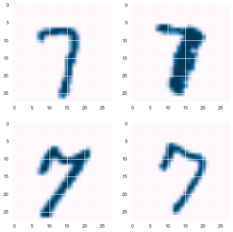

```python
#画出随便挑选的四个数
plt.figure(figsize=(8,8))
ax1 = plt.subplot(221)
ax2 = plt.subplot(222)
ax3 = plt.subplot(223)
ax4 = plt.subplot(224)
plt.sca(ax1)
plt.imshow(train_plot[103],cmap=cm.PuBu)
plt.sca(ax2)
plt.imshow(train_plot[30168],cmap=cm.PuBu)
plt.sca(ax3)
plt.imshow(test_plot[104],cmap=cm.PuBu)
plt.sca(ax4)
plt.imshow(test_plot[20000],cmap=cm.PuBu)
plt.show()
```

## 2.特征工程

### 2.1 像素处理

```python
#合并训练数据和测试数据的像素（自变量）
Xt=np.vstack((X_train,test))
print len(X_train)
print len(Xt)
```

```
42000
70000
```

```python
#为简化，将像素0,1化
for i in range(70000):
    for j in range(784):
        if Xt[i,j]!=0:
            Xt[i,j]=1
```

```python
#像素统一转变为28*28的矩阵
Xt1= np.array(Xt).reshape((-1, 28, 28)).astype(np.uint8)
Xt1.shape
```

```
(70000L, 28L, 28L)
```

```
[[0 0 0 0 0 0 0 0 0 0 0 0 0 0 0 0 0 0 0 0 0 0 0 0 0 0 0 0]
 [0 0 0 0 0 0 0 0 0 0 0 0 0 0 0 0 0 0 0 0 0 0 0 0 0 0 0 0]
 [0 0 0 0 0 0 0 0 0 0 0 0 0 0 0 0 0 0 0 0 0 0 0 0 0 0 0 0]
 [0 0 0 0 0 0 0 0 0 0 0 0 0 0 0 0 0 0 0 0 0 0 0 0 0 0 0 0]
 [0 0 0 0 0 0 0 0 0 0 0 0 0 0 0 0 0 0 0 0 0 0 0 0 0 0 0 0]
 [0 0 0 0 0 0 0 0 0 0 0 0 0 0 0 0 0 0 0 0 0 0 0 0 0 0 0 0]
 [0 0 0 0 0 0 0 0 0 0 0 1 1 1 1 1 1 1 1 0 0 0 0 0 0 0 0 0]
 [0 0 0 0 0 0 0 0 0 0 0 1 1 1 1 1 1 1 1 1 0 0 0 0 0 0 0 0]
 [0 0 0 0 0 0 0 0 0 0 1 1 1 1 1 0 0 1 1 1 0 0 0 0 0 0 0 0]
 [0 0 0 0 0 0 0 0 0 0 1 1 1 1 0 0 0 1 1 1 0 0 0 0 0 0 0 0]
 [0 0 0 0 0 0 0 0 0 0 1 1 1 1 0 0 0 1 1 1 0 0 0 0 0 0 0 0]
 [0 0 0 0 0 0 0 0 0 0 1 1 1 0 0 0 0 1 1 1 0 0 0 0 0 0 0 0]
 [0 0 0 0 0 0 0 0 0 0 1 1 1 1 0 1 1 1 1 1 0 0 0 0 0 0 0 0]
 [0 0 0 0 0 0 0 0 0 0 1 1 1 1 0 1 1 1 1 0 0 0 0 0 0 0 0 0]
 [0 0 0 0 0 0 0 0 0 0 0 1 1 1 1 1 1 1 1 0 0 0 0 0 0 0 0 0]
 [0 0 0 0 0 0 0 0 0 0 0 1 1 1 1 1 1 1 1 0 0 0 0 0 0 0 0 0]
 [0 0 0 0 0 0 0 0 0 0 0 0 0 1 1 1 1 1 1 0 0 0 0 0 0 0 0 0]
 [0 0 0 0 0 0 0 0 0 0 0 0 0 0 1 1 1 1 0 0 0 0 0 0 0 0 0 0]
 [0 0 0 0 0 0 0 0 0 0 0 0 0 1 1 1 1 1 0 0 0 0 0 0 0 0 0 0]
 [0 0 0 0 0 0 0 0 0 0 0 0 0 1 1 1 1 1 0 0 0 0 0 0 0 0 0 0]
 [0 0 0 0 0 0 0 0 0 0 0 0 0 1 1 1 1 0 0 0 0 0 0 0 0 0 0 0]
 [0 0 0 0 0 0 0 0 0 0 0 0 1 1 1 1 1 0 0 0 0 0 0 0 0 0 0 0]
 [0 0 0 0 0 0 0 0 0 0 0 0 1 1 1 1 1 0 0 0 0 0 0 0 0 0 0 0]
 [0 0 0 0 0 0 0 0 0 0 0 0 1 1 1 1 0 0 0 0 0 0 0 0 0 0 0 0]
 [0 0 0 0 0 0 0 0 0 0 0 0 1 1 1 1 0 0 0 0 0 0 0 0 0 0 0 0]
 [0 0 0 0 0 0 0 0 0 0 0 0 1 1 1 0 0 0 0 0 0 0 0 0 0 0 0 0]
 [0 0 0 0 0 0 0 0 0 0 0 0 0 0 0 0 0 0 0 0 0 0 0 0 0 0 0 0]
 [0 0 0 0 0 0 0 0 0 0 0 0 0 0 0 0 0 0 0 0 0 0 0 0 0 0 0 0]]
```

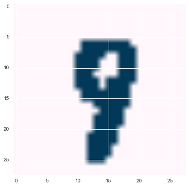

```python
#随便选一个数查看
print Xt1[161]
plt.figure(figsize=(6,6))
plt.imshow(Xt1[161],cmap=cm.PuBu)
plt.show()
```

### 2.2 特征提取

```python
f1=np.zeros((70000,7))
for i in range(70000):
    for j in range(7):
        f1[i,j]=sum(sum(Xt1[i][4*j:4*j+4]))#每4行计算总和作为一个特征
f1.shape#每个数有28行，故产生7个特征
```

```
(70000L, 7L)
```

```python
f2=np.zeros((70000,7))
for i in range(70000):
    for j in range(7):
        f2[i,j]=sum(sum(Xt1[i].T[4*j:4*j+4]))#每4列计算总和作为一个特征
f2.shape#每个数有28列，故又产生7个特征
```

```
(70000L, 7L)
```

```python
f3=np.zeros((70000,4,4))
for i in range(70000):
    for j in range(4):#将28*28分割成16个7*7的小矩阵，对每个小矩阵求和
        for k in range(4):
            f3[i][j,k]=sum(sum(Xt1[i][7*j:7*j+7,7*k:7*k+7]))#共产生16个特征
f3=f3.reshape(70000,16)
```

```python
f4=np.zeros((70000,3))
for i in range(70000):
    f4[i][0]=sum(sum(Xt1[i][11:16,11:16]))#选取最中间6行6列总和作为一个特征

    num1=np.zeros(28)
    for j in range(28):
        num1[j]=sum(Xt1[i][j])#求出每一列的和
    f4[i][1]=max(num1)         #把最大的“列和”作为一个特征

    num2=np.zeros(28)
    for j in range(28):
        num2[j]=sum(Xt1[i].T[j])#求出每一行的和
    f4[i][2]=max(num2)            #把最大的“行和”作为一个特征

f4.shape#又产生3个特征
```

```
(70000L, 3L)
```

```python
f5=np.zeros((70000,2))
for i in range(70000):
    for j in range(784):#第一个1出现在第几列作为一个特征
        if Xt[i][j]!=0:
            break
    f5[i][0]=(j+1)%28

    for j in range(784)[::-1]:#最后一个1出现在第几列作为一个特征
        if Xt[i][j]!=0:
            break
    f5[i][1]=(j+1)%28
f5.shape#又产生2个特征
```

```
(70000L, 2L)
```

```python
#合并所有新特征
features=np.hstack((f1,f2,f3,f4,f5))
print features.shape
features1=features[:42000]#训练数据的新特征
features2=features[42000:]#测试数据的新特征
```

```
(70000L, 35L)
```

## 3. Logistic回归

```python
from sklearn.linear_model import LogisticRegression
```

### 3.1 Ridge正则化

```python
ridge=LogisticRegression(penalty='l2', solver ='lbfgs', multi_class='multinomial', max_iter=800,  C=0.2 )
```

- l2=Ridge，lbfgs=拟牛顿法（多分类问题用牛顿迭代法newton-cg或拟牛顿法lbfgs计算损失函数最小值更好，这两个方法只能应用于L2）， multinomial是为了对应lbfgs， max_iter设置为迭代800次，惩罚项系数C设为0.2，实际上是1/0.2，参数调整方法详见[sklearn使用手册](http://scikit-learn.org/0.17/user_guide.html)

```python
ridge.fit(features1, y_train)
pred_ridge=ridge.predict(features1)
print pd.value_counts(pred_ridge==y_train)
```

```
True     37371
False     4629
dtype: int64
```

```python
#计算正确率
37371.001/42000
```

```
0.889785738095238
```

### 3.2 Lasso正则化

```python
lasso=LogisticRegression(penalty='l1', multi_class='ovr', max_iter=400,  C=4 )
```

- l1=Lasso，多分类方法选择ovr，迭代400次，惩罚项系数设为4

```python
lasso.fit(features1, y_train)
pred_lasso=lasso.predict(features1)
print pd.value_counts(pred_lasso==y_train)
```

```
True     37023
False     4977
dtype: int64
```

```python
37023.001/42000
```

```
0.8815000238095237
```

## 4. K邻近算法

### 4.1 KNN建模

```python
from sklearn.neighbors import KNeighborsClassifier
from sklearn.cross_validation import cross_val_score
```

```python
knn = KNeighborsClassifier().fit(features1, y_train)
```

```python
#计算交叉验证得分
print cross_val_score(knn, features1, y_train)
```

```
[ 0.90688375  0.90627232  0.91098728]
```

### 4.2 画混淆矩阵

```python
pred=knn.predict(features1).astype(int)
```

```python
print pd.value_counts(pred==y_train)
mix=pd.crosstab(y_train,pred)
mix.columns.names=['Predict']
mix.index.names=['Real']
mix
```

```
True     39535
False     2465
dtype: int64
```

| Predict Real | 0 | 1 | 2 | 3 | 4 | 5 | 6 | 7 | 8 | 9 |
| --- | --- | --- | --- | --- | --- | --- | --- | --- | --- | --- |
| 0 | 4071 | 4 | 0 | 1 | 5 | 1 | 8 | 1 | 38 | 3 |
| 1 | 1 | 4624 | 12 | 8 | 1 | 8 | 7 | 4 | 11 | 8 |
| 2 | 70 | 9 | 3972 | 37 | 16 | 2 | 23 | 19 | 27 | 2 |
| 3 | 32 | 17 | 58 | 3971 | 13 | 55 | 2 | 45 | 121 | 37 |
| 4 | 10 | 4 | 14 | 1 | 3681 | 5 | 24 | 4 | 1 | 328 |
| 5 | 38 | 4 | 16 | 153 | 20 | 3363 | 47 | 6 | 120 | 28 |
| 6 | 22 | 7 | 6 | 1 | 14 | 12 | 4058 | 0 | 16 | 1 |
| 7 | 3 | 27 | 23 | 7 | 39 | 3 | 3 | 4126 | 8 | 162 |
| 8 | 72 | 44 | 8 | 48 | 24 | 66 | 26 | 4 | 3747 | 24 |
| 9 | 18 | 7 | 1 | 44 | 100 | 11 | 3 | 57 | 25 | 3922 |

- 除了对角线上元素之外，观察一些预测错的三位数也能为改进该模型（提取新的特征）指明一些方向，比如328、153、162

```python
39535.0001/42000
```

```
0.9413095261904761
```

```python
#要提交的结果
knn_output = knn.predict(features2).astype(int)
```

```python
np.savetxt('submission_knn.csv', np.c_[range(1,28001),knn_output], delimiter=',', header = 'ImageId,Label', comments = '', fmt='%d')
```

- 真实正确率为91.7%